# DogBreed_Analysis

HunorKis

2022-12-23

# Background for the project

## Core idea:

I would like to investigate the most important aspects by which we decide to buy a dog. It is a broadly discussed in dog related communites that Hungaricum dogbreeds are less and less chosen. To learn more about this topic you might want to check the [Ki kutyája vagyok én?](https://port.hu/adatlap/film/mozi/ki-kutyaja-vagyok-en-ki-kutyaja-vagyok-en-whose-dog-am-i/movie-243298) - titled movie, that was recently premiered.

I want to investigate the most important factors that define a top level dog and then I would like to create a model about the most important predictors. Finally, I hope that I will see these predictor values to be lower in Hungarian breeds and that would serv as some sort of explanation.

Read the dataset + add packages: To read the data I have used a simple readr method with the links for the dataset available on Github.

```r
library(tidyverse)
library(dplyr)
library(car)
breed_traits <- readr::read_csv('https://raw.githubusercontent.com/rfordatascience/tidytuesday/master/data/2022/2022-02-01/breed_traits.csv')
trait_description <- readr::read_csv('https://raw.githubusercontent.com/rfordatascience/tidytuesday/master/data/2022/2022-02-01/trait_description.csv')
breed_rank_all <- readr::read_csv('https://raw.githubusercontent.com/rfordatascience/tidytuesday/master/data/2022/2022-02-01/breed_rank.csv')
```

Getting the data that I want to analyse: First of all, I needed to combine the two datasets for easier handling. All the changes will be find in this chunk.

```r
#Combine dataframes:
df_main <- cbind( breed_traits, breed_rank_all[2:9])



#remove spaces from colnames:
colnames(df_main) <- gsub(" ", "_", colnames(df_main))
colnames(df_main) <- gsub("/", "_", colnames(df_main))


#change colnames where number:

colnames(df_main)[18] <- "Rank_2013"
colnames(df_main)[19] <- "Rank_2014"
colnames(df_main)[20] <- "Rank_2015"
colnames(df_main)[21] <- "Rank_2016"
colnames(df_main)[22] <- "Rank_2017"
colnames(df_main)[23] <- "Rank_2018"
colnames(df_main)[24] <- "Rank_2019"
colnames(df_main)[25] <- "Rank_2020"

#Main table: since there are too much ranks to be handled, I added an extra column with popularity rankings, I have also filtered those that appear only in the 2020 ranking
bins <-c(0, 35, 70 , 105, 140, Inf)

df_main <- df_main %>%
  filter(!is.na(Rank_2013)) %>%
  mutate(Rank_cat = cut(Rank_2020, breaks = bins, labels = c("HighestRanking", "GoodRanking", "MediumRanking", "MediumLowRanking", "LowRanking"))) %>%
  mutate(Coat_Type = as.factor(Coat_Type))
```

# EA: In this section I will explore the dataset

## Top 10 most and least popular breed

```r
head(df_main, 10)
```

```
##                            Breed Affectionate_With_Family
## 1          Retrievers (Labrador)                        5
## 2                French Bulldogs                        5
## 3           German Shepherd Dogs                        5
## 4            Retrievers (Golden)                        5
## 5                       Bulldogs                        4
## 6                        Poodles                        5
## 7                        Beagles                        3
## 8                    Rottweilers                        5
## 9  Pointers (German Shorthaired)                        5
## 10                    Dachshunds                        5
##    Good_With_Young_Children Good_With_Other_Dogs Shedding_Level
## 1                         5                    5              4
## 2                         5                    4              3
## 3                         5                    3              4
```

[output cut: 62 more lines]

```r
tail(df_main, 10)
```

```
##                           Breed Affectionate_With_Family
## 167               Skye Terriers                        5
## 168                 Canaan Dogs                        3
## 169 American English Coonhounds                        3
## 170                    Chinooks                        4
## 171               Finnish Spitz                        5
## 172                    Harriers                        5
## 173              Cesky Terriers                        4
## 174          American Foxhounds                        3
## 175           English Foxhounds                        5
## 176        Norwegian Lundehunds                        3
##     Good_With_Young_Children Good_With_Other_Dogs Shedding_Level
## 167                        3                    3              3
## 168                        3                    3              4
## 169                        3                    5              2
```

[output cut: 62 more lines]

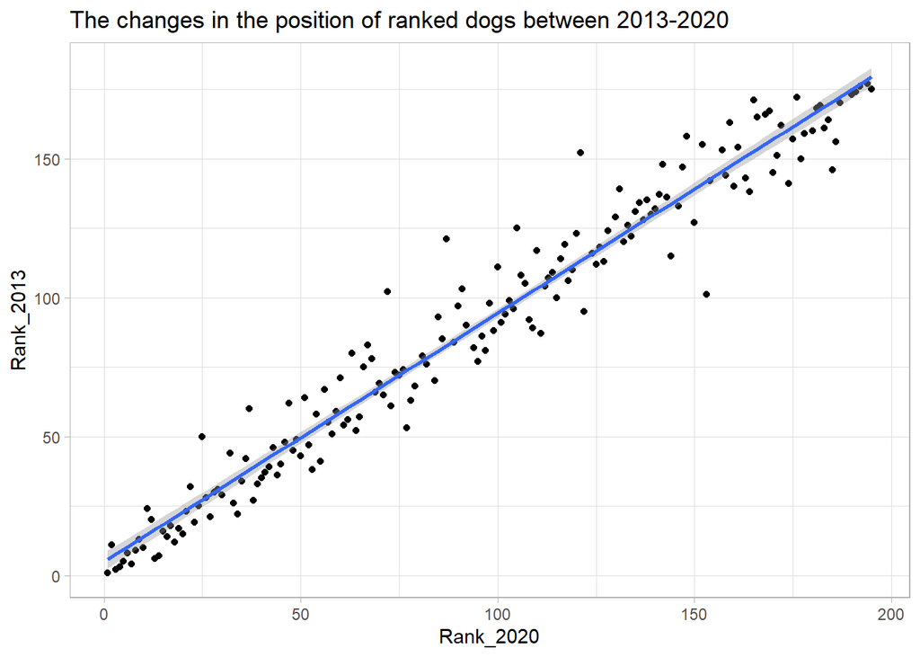

```r
df_main %>%
  ggplot()+
  aes(x = Rank_2020, y = Rank_2013)+
  geom_point()+
  geom_smooth(method='lm')+
  theme_light()+
  labs(title = "The changes in the position of ranked dogs between 2013-2020")
```

# From here on, I would like to analyze the characteristics of the most popular and least popular dogs from 2020

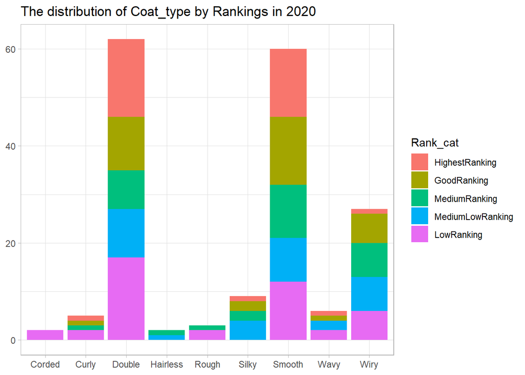

```r
df_main %>%
  ggplot()+
  aes(x = Coat_Type, fill = Rank_cat) +
  geom_bar()+
  theme_light()+
  labs(title = "The distribution of Coat_type by Rankings in 2020",y = NULL, x = NULL)
```

## Now we will check the metrics that could predict how would the dog interact with people and dogs.

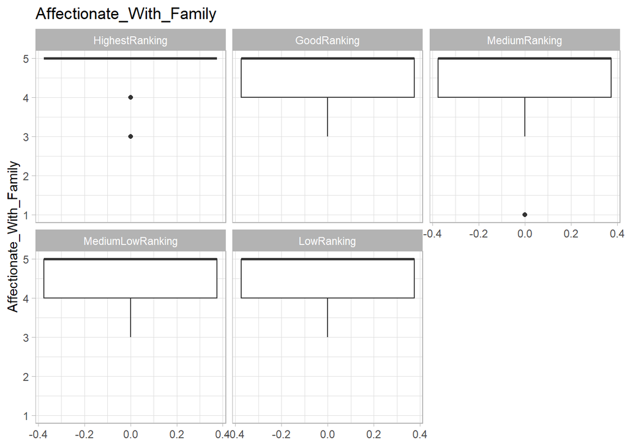

```r
df_main %>%
  ggplot()+
  aes(y = Affectionate_With_Family)+
  geom_boxplot()+
  facet_wrap(~ Rank_cat)+
  theme_light()+
  labs(title = "Affectionate_With_Family")
```

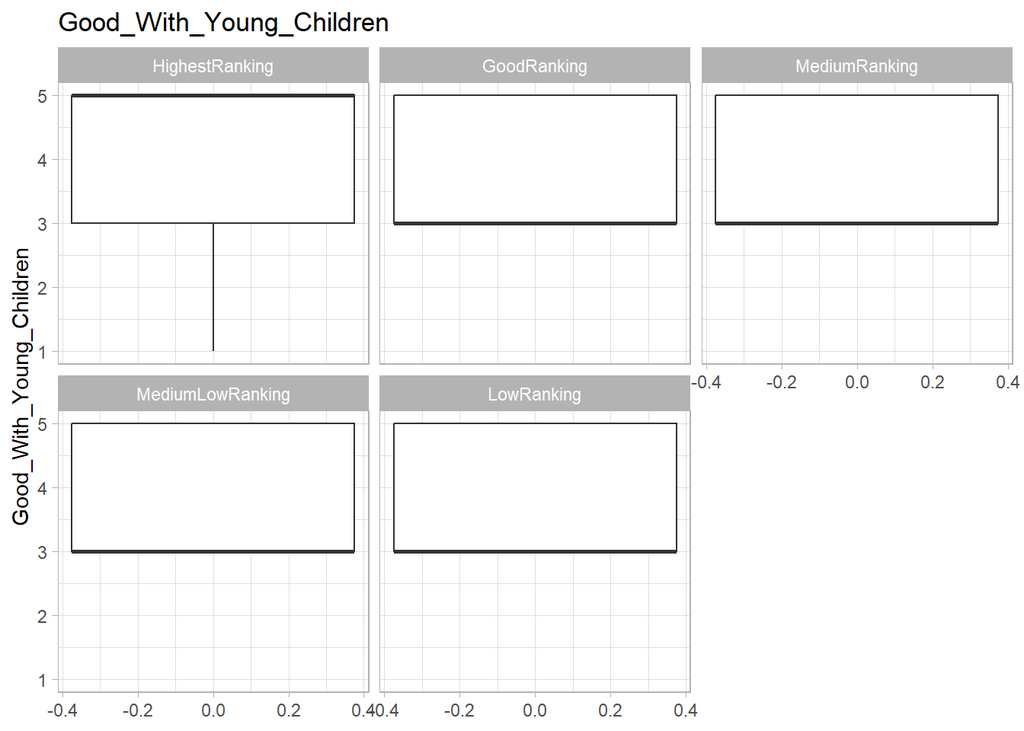

```r
df_main %>%
  ggplot()+
  aes(y = Good_With_Young_Children)+
  geom_boxplot()+
  facet_wrap(~ Rank_cat) +
  theme_light()+
  labs(title = "Good_With_Young_Children")
```

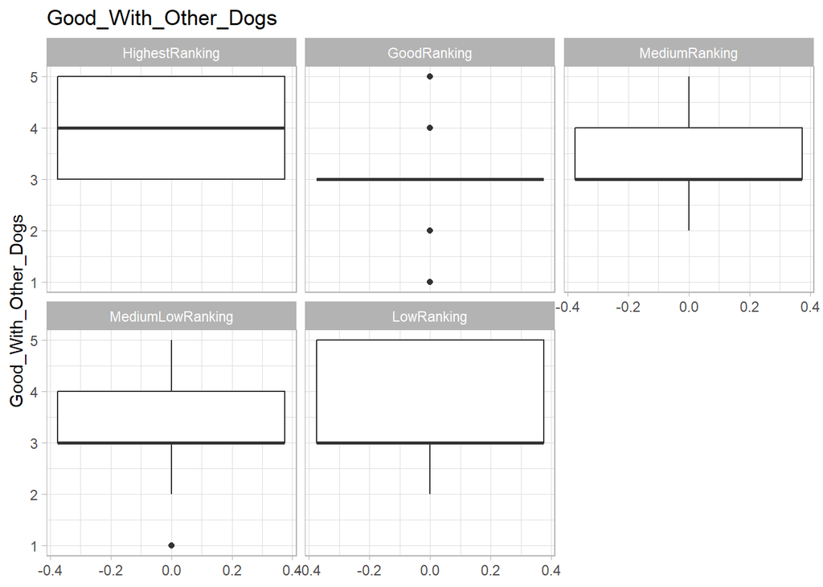

```r
df_main %>%
  ggplot()+
  aes(y = Good_With_Other_Dogs)+
  geom_boxplot()+
  facet_wrap(~ Rank_cat) +
  theme_light()+
  labs(title = "Good_With_Other_Dogs")
```

## Now I want to further investigate the coat type and popularity

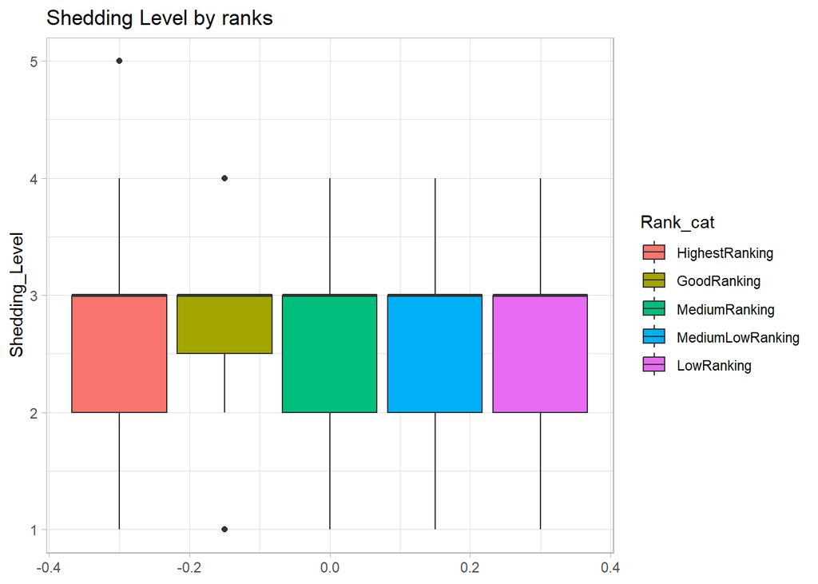

```r
df_main %>%
  ggplot()+
  aes(y = Shedding_Level, fill = Rank_cat)+
  geom_boxplot() +
  theme_light()+
  labs(title = "Shedding Level by ranks")
```

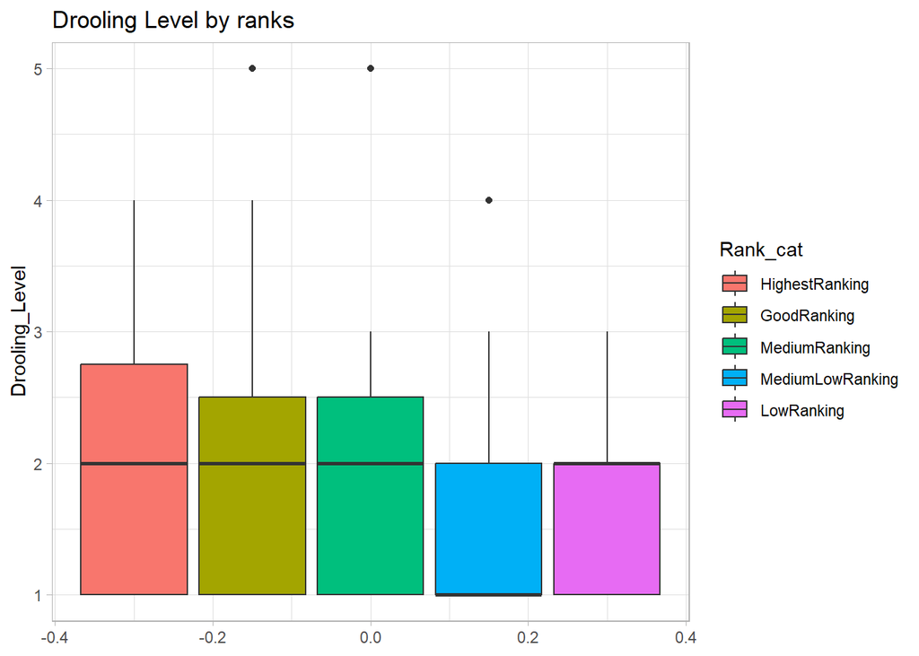

```r
df_main %>%
  ggplot()+
  aes(y = Drooling_Level, fill = Rank_cat)+
  geom_boxplot()+
  theme_light()+
  labs(title = "Drooling Level by ranks")
```

## Now I will check how other role related information can impact the judgement

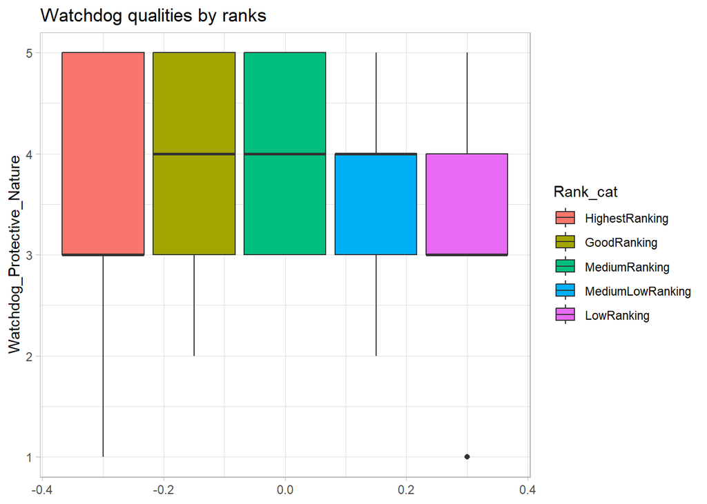

```r
df_main %>%
  ggplot()+
  aes(y= Watchdog_Protective_Nature, fill = Rank_cat)+
  geom_boxplot() +
  theme_light()+
  labs(title = "Watchdog qualities by ranks")
```

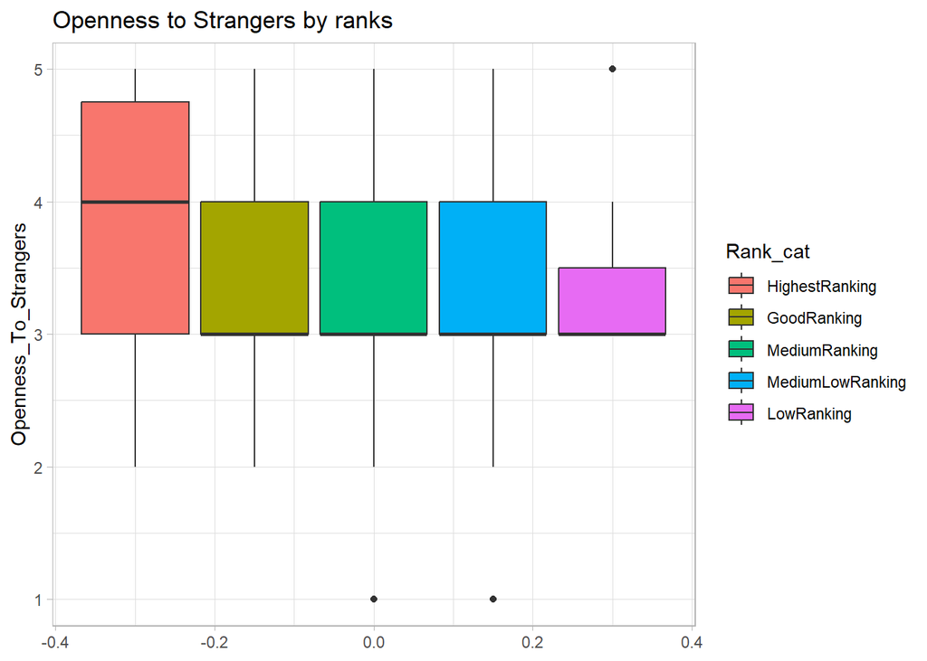

```r
df_main %>%
  ggplot()+
  aes(y= Openness_To_Strangers, fill = Rank_cat)+
  geom_boxplot()  +
  theme_light()+
  labs(title = "Openness to Strangers by ranks")
```

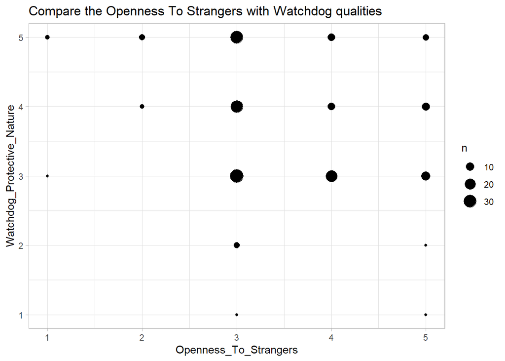

```r
#Presumable there is a correlation between the protectiveness and openness_To_Strangers

df_main %>%
  ggplot()+
  aes(x= Openness_To_Strangers, y = Watchdog_Protective_Nature)+
  geom_count()+
  theme_light()+
  labs(title = "Compare the Openness To Strangers with Watchdog qualities")
```

```r
cor.test(df_main$Openness_To_Strangers, df_main$Watchdog_Protective_Nature )
```

```
##
##  Pearson's product-moment correlation
##
## data:  df_main$Openness_To_Strangers and df_main$Watchdog_Protective_Nature
## t = -2.7154, df = 174, p-value = 0.007287
## alternative hypothesis: true correlation is not equal to 0
## 95 percent confidence interval:
##  -0.33942201 -0.05535589
## sample estimates:
##       cor
## -0.201625
```

Unfortunately, I could not find a strong correlation between the Openness_To_Strangers and Watchdog_traits..

## Finally I would like to check the Trainability and Adaptability

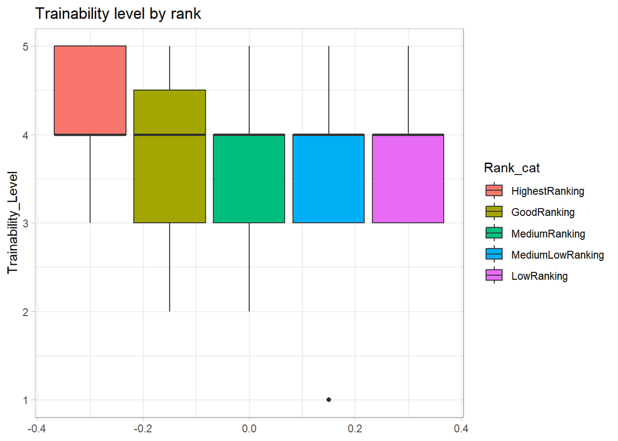

```r
df_main %>%
  ggplot()+
  aes(y= Trainability_Level, fill = Rank_cat)+
  geom_boxplot() +
  theme_light()+
  labs(title = "Trainability level by rank")
```

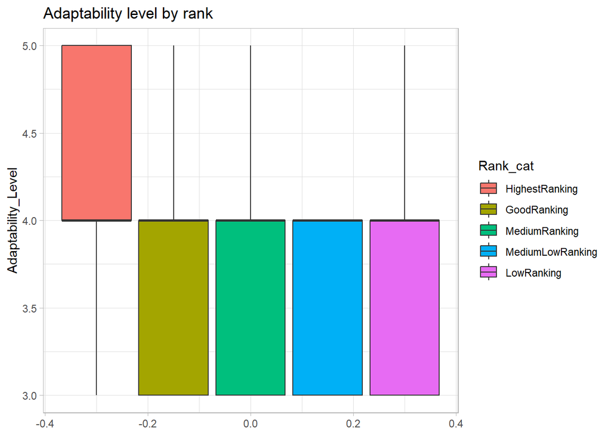

```r
df_main %>%
  ggplot()+
  aes(y= Adaptability_Level, fill = Rank_cat)+
  geom_boxplot() +
  theme_light()+
  labs(title = "Adaptability level by rank")
```

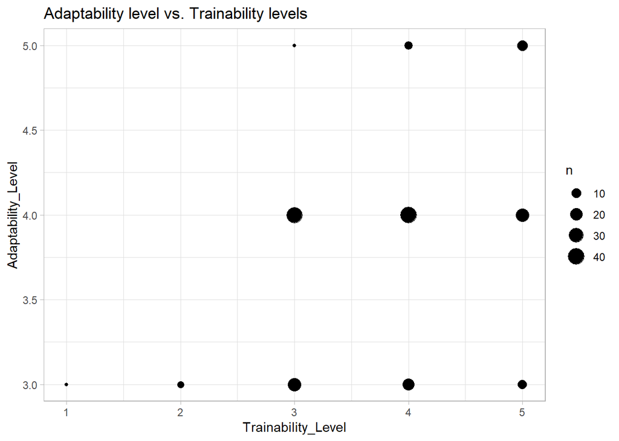

```r
#Here, I also wanted to see the interaction:

df_main %>%
  ggplot() +
  aes(x = Trainability_Level, y = Adaptability_Level) +
  geom_count()+
  theme_light()+
  labs(title = "Adaptability level vs. Trainability levels")
```

```r
cor.test(df_main$Adaptability_Level, df_main$Trainability_Level )
```

```
##
##  Pearson's product-moment correlation
##
## data:  df_main$Adaptability_Level and df_main$Trainability_Level
## t = 4.9514, df = 174, p-value = 1.732e-06
## alternative hypothesis: true correlation is not equal to 0
## 95 percent confidence interval:
##  0.2146628 0.4746696
## sample estimates:
##       cor
## 0.3514241
```

# Building Models

```r
Ranking_Model_Complex <- lm(Rank_2020~ Affectionate_With_Family + Good_With_Young_Children + Good_With_Other_Dogs + Watchdog_Protective_Nature + Openness_To_Strangers + Adaptability_Level + Trainability_Level, data = df_main)

summary(Ranking_Model_Complex)
```

```
##
## Call:
## lm(formula = Rank_2020 ~ Affectionate_With_Family + Good_With_Young_Children +
##     Good_With_Other_Dogs + Watchdog_Protective_Nature + Openness_To_Strangers +
##     Adaptability_Level + Trainability_Level, data = df_main)
##
## Residuals:
##     Min      1Q  Median      3Q     Max
## -97.370 -41.160  -4.416  41.414 105.077
##
## Coefficients:
##                            Estimate Std. Error t value Pr(>|t|)
## (Intercept)                 213.021     38.810   5.489 1.47e-07 ***
## Affectionate_With_Family      8.135      6.223   1.307   0.1929
## Good_With_Young_Children     -6.804      4.787  -1.421   0.1571
## Good_With_Other_Dogs          1.571      5.231   0.300   0.7643
## Watchdog_Protective_Nature  -10.653      5.138  -2.073   0.0397 *
## Openness_To_Strangers       -12.787      5.542  -2.307   0.0223 *
## Adaptability_Level           -7.771      8.674  -0.896   0.3716
## Trainability_Level           -5.379      5.170  -1.040   0.2996
## ---
## Signif. codes:  0 '***' 0.001 '**' 0.01 '*' 0.05 '.' 0.1 ' ' 1
##
## Residual standard error: 53.94 on 168 degrees of freedom
## Multiple R-squared:  0.1067, Adjusted R-squared:  0.06945
## F-statistic: 2.866 on 7 and 168 DF,  p-value: 0.007502
```

```r
Ranking_Model_FamilyTraits <- lm(Rank_2020~ Affectionate_With_Family + Good_With_Young_Children + Good_With_Other_Dogs, data = df_main)

summary(Ranking_Model_FamilyTraits)
```

```
##
## Call:
## lm(formula = Rank_2020 ~ Affectionate_With_Family + Good_With_Young_Children +
##     Good_With_Other_Dogs, data = df_main)
##
## Residuals:
##     Min      1Q  Median      3Q     Max
## -96.875 -45.010  -1.527  44.127 111.585
##
## Coefficients:
##                          Estimate Std. Error t value Pr(>|t|)
## (Intercept)               127.268     27.783   4.581 8.86e-06 ***
## Affectionate_With_Family   -1.618      5.361  -0.302   0.7632
## Good_With_Young_Children  -11.230      4.577  -2.453   0.0151 *
## Good_With_Other_Dogs        4.922      4.777   1.030   0.3043
## ---
## Signif. codes:  0 '***' 0.001 '**' 0.01 '*' 0.05 '.' 0.1 ' ' 1
##
## Residual standard error: 55.31 on 172 degrees of freedom
## Multiple R-squared:  0.03802,    Adjusted R-squared:  0.02124
## F-statistic: 2.266 on 3 and 172 DF,  p-value: 0.08263
```

```r
Ranking_Model_role <- lm(Rank_2020~ Watchdog_Protective_Nature + Openness_To_Strangers + Adaptability_Level + Trainability_Level, data = df_main)

summary(Ranking_Model_role)
```

```
##
## Call:
## lm(formula = Rank_2020 ~ Watchdog_Protective_Nature + Openness_To_Strangers +
##     Adaptability_Level + Trainability_Level, data = df_main)
##
## Residuals:
##      Min       1Q   Median       3Q      Max
## -113.612  -44.707   -2.651   41.809  101.944
##
## Coefficients:
##                            Estimate Std. Error t value Pr(>|t|)
## (Intercept)                 217.296     33.126   6.560 6.16e-10 ***
## Watchdog_Protective_Nature   -9.418      4.529  -2.080   0.0391 *
## Openness_To_Strangers       -13.086      5.270  -2.483   0.0140 *
## Adaptability_Level           -5.257      7.461  -0.705   0.4821
## Trainability_Level           -5.854      5.160  -1.135   0.2581
## ---
## Signif. codes:  0 '***' 0.001 '**' 0.01 '*' 0.05 '.' 0.1 ' ' 1
##
## Residual standard error: 54.04 on 171 degrees of freedom
## Multiple R-squared:  0.08718,    Adjusted R-squared:  0.06583
## F-statistic: 4.083 on 4 and 171 DF,  p-value: 0.003468
```

```r
anova(Ranking_Model_Complex, Ranking_Model_FamilyTraits)
```

```
## Analysis of Variance Table
##
## Model 1: Rank_2020 ~ Affectionate_With_Family + Good_With_Young_Children +
##     Good_With_Other_Dogs + Watchdog_Protective_Nature + Openness_To_Strangers +
##     Adaptability_Level + Trainability_Level
## Model 2: Rank_2020 ~ Affectionate_With_Family + Good_With_Young_Children +
##     Good_With_Other_Dogs
##   Res.Df    RSS Df Sum of Sq      F  Pr(>F)
## 1    168 488718
## 2    172 526277 -4    -37558 3.2277 0.01392 *
## ---
## Signif. codes:  0 '***' 0.001 '**' 0.01 '*' 0.05 '.' 0.1 ' ' 1
```

```r
anova(Ranking_Model_Complex, Ranking_Model_role)
```

```
## Analysis of Variance Table
##
## Model 1: Rank_2020 ~ Affectionate_With_Family + Good_With_Young_Children +
##     Good_With_Other_Dogs + Watchdog_Protective_Nature + Openness_To_Strangers +
##     Adaptability_Level + Trainability_Level
## Model 2: Rank_2020 ~ Watchdog_Protective_Nature + Openness_To_Strangers +
##     Adaptability_Level + Trainability_Level
##   Res.Df    RSS Df Sum of Sq      F Pr(>F)
## 1    168 488718
## 2    171 499381 -3    -10663 1.2218 0.3035
```

```r
anova( Ranking_Model_role, Ranking_Model_FamilyTraits)
```

```
## Analysis of Variance Table
##
## Model 1: Rank_2020 ~ Watchdog_Protective_Nature + Openness_To_Strangers +
##     Adaptability_Level + Trainability_Level
## Model 2: Rank_2020 ~ Affectionate_With_Family + Good_With_Young_Children +
##     Good_With_Other_Dogs
##   Res.Df    RSS Df Sum of Sq      F   Pr(>F)
## 1    171 499381
## 2    172 526277 -1    -26896 9.2097 0.002784 **
## ---
## Signif. codes:  0 '***' 0.001 '**' 0.01 '*' 0.05 '.' 0.1 ' ' 1
```

# Choosen model + Assumption check:

## Summary of the model

```r
summary(Ranking_Model_FamilyTraits)
```

```
##
## Call:
## lm(formula = Rank_2020 ~ Affectionate_With_Family + Good_With_Young_Children +
##     Good_With_Other_Dogs, data = df_main)
##
## Residuals:
##     Min      1Q  Median      3Q     Max
## -96.875 -45.010  -1.527  44.127 111.585
##
## Coefficients:
##                          Estimate Std. Error t value Pr(>|t|)
## (Intercept)               127.268     27.783   4.581 8.86e-06 ***
## Affectionate_With_Family   -1.618      5.361  -0.302   0.7632
## Good_With_Young_Children  -11.230      4.577  -2.453   0.0151 *
## Good_With_Other_Dogs        4.922      4.777   1.030   0.3043
## ---
## Signif. codes:  0 '***' 0.001 '**' 0.01 '*' 0.05 '.' 0.1 ' ' 1
##
## Residual standard error: 55.31 on 172 degrees of freedom
## Multiple R-squared:  0.03802,    Adjusted R-squared:  0.02124
## F-statistic: 2.266 on 3 and 172 DF,  p-value: 0.08263
```

## Check for outliers

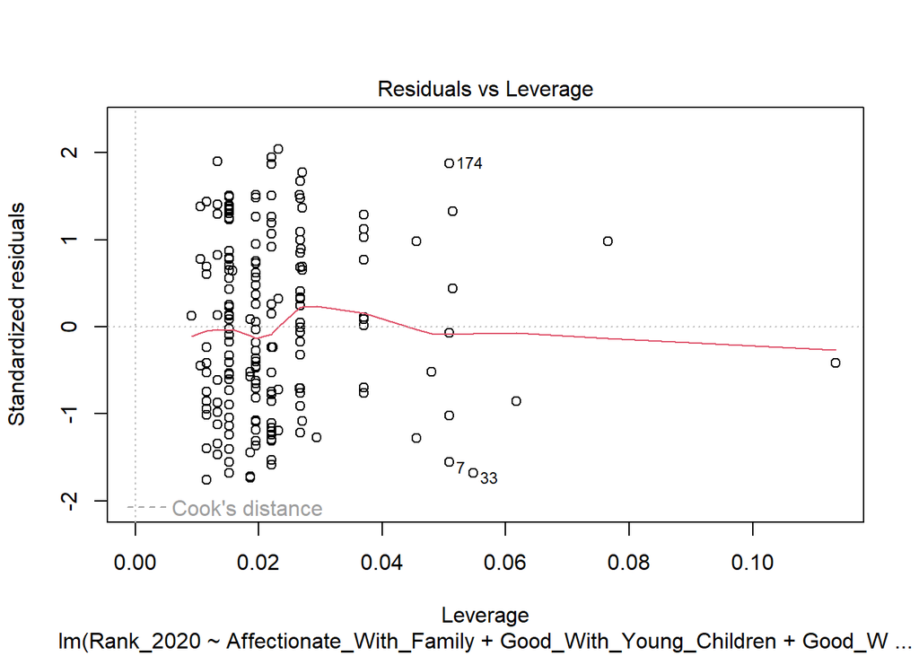

```r
plot(Ranking_Model_FamilyTraits, which = 5)
```

## Checking normality

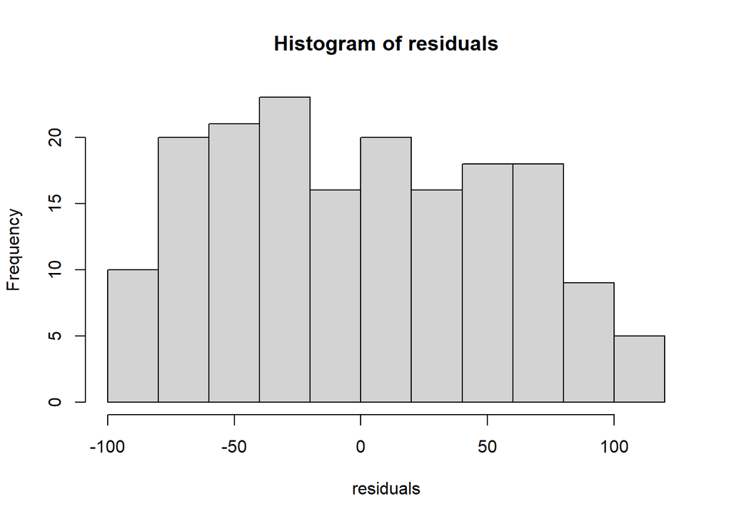

```r
residuals <- residuals(Ranking_Model_FamilyTraits)
hist(residuals)
```

## Checking linearity

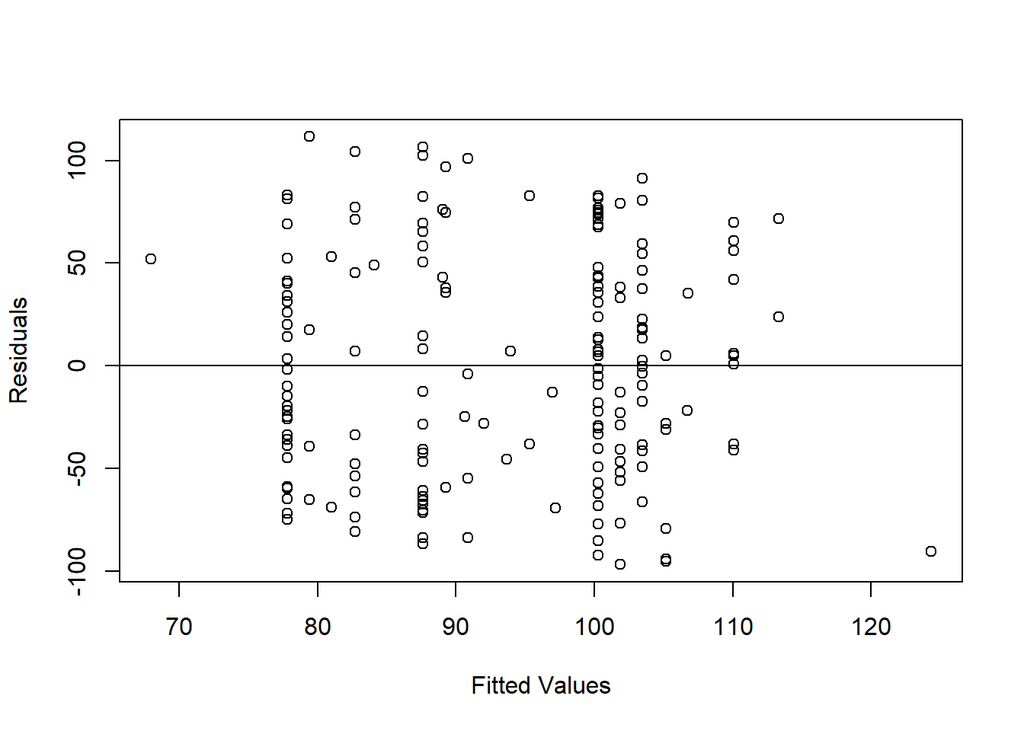

```r
fitted_values <- fitted(Ranking_Model_FamilyTraits)
plot(fitted_values, residuals, xlab = "Fitted Values", ylab = "Residuals")
abline(h = 0)
```

## Checking Multicollinearity

```r
vifs <- vif(Ranking_Model_FamilyTraits)

vifs
```

```
## Affectionate_With_Family Good_With_Young_Children     Good_With_Other_Dogs
##                 1.070873                 1.206174                 1.147244
```

# Looking at the data of Hungarian dogs

```r
df_hungarian <- df_main %>%
  filter(Breed %in% c("Komondorok", "Kuvaszok", "Pulik"))



df_hungarian[, c("Breed","Affectionate_With_Family", "Good_With_Young_Children", "Good_With_Other_Dogs", "Rank_2020")]
```

```
##        Breed Affectionate_With_Family Good_With_Young_Children
## 1      Pulik                        5                        3
## 2   Kuvaszok                        5                        3
## 3 Komondorok                        5                        3
##   Good_With_Other_Dogs Rank_2020
## 1                    3       143
## 2                    3       177
## 3                    2       178
```